# Prototipação do Tratamento entre iterações

Neste notebook estão os testes usados para definir como será a seleção de labels entre cada iteração do modelo

# Setup

```python
import sys
sys.path.append('..')

from osgeo import gdal
import os
import numpy as np

import matplotlib.pyplot as plt
import matplotlib.image as mpimg
import matplotlib.patches as patches

import seaborn as sns

from skimage.measure import label, regionprops, regionprops_table

from skimage.io import imshow

from src.utils import read_tiff, load_norm, array2raster, read_yaml
from src.metrics import evaluate_metrics, evaluate_metrics_pred

import pandas as pd

import seaborn as sns

import torch

from imblearn.under_sampling import RandomUnderSampler
sns.set_theme(style="darkgrid")
```

```python
args = read_yaml('../args.yaml')
```

```python
current_iter_folder = "/home/luiz/multi-task-fcn/MyData/iter_1"
```

```python
def show(img, title=None):
    fig, ax = plt.subplots(figsize=(7, 15))
    ax.imshow(img)
    if title:
        ax.set_title(title)
    ax.set_xticks([])
    ax.set_yticks([])
    return fig, ax
```

```python
itc = False
sum_overlap = 1.1
```

# Visão dos resultados da primeira iteração

```python
# ortho = read_tiff("/home/luiz/multi-task-fcn/Data/orthoimages/fixed_ortoA1_25tiff.tif")
# read tiff with gdal
gdal_header = gdal.Open("/home/luiz/multi-task-fcn/Data/orthoimages/fixed_ortoA1_25tiff.tif")
# get raster band as satellite image
gdal_raster = gdal_header.GetRasterBand(gdal_header.RasterCount)
# read as numpy array
ortho = gdal_raster.ReadAsArray()
```

```python
depth_path = os.path.join(current_iter_folder, "raster_prediction",  f"depth_itc{itc}_{sum_overlap}.TIF")
prob_path = os.path.join(current_iter_folder, "raster_prediction",  f"join_prob_itc{itc}_{sum_overlap}.TIF")
pred_path = os.path.join(current_iter_folder, "raster_prediction",  f"join_class_itc{itc}_{sum_overlap}.TIF")

depth = read_tiff(depth_path)
prob = read_tiff(prob_path)
pred = read_tiff(pred_path)
```

```
/home/luiz/multi-task-fcn/MyData/iter_1/raster_prediction/depth_itcFalse_1.1.TIF
/home/luiz/multi-task-fcn/MyData/iter_1/raster_prediction/join_prob_itcFalse_1.1.TIF
/home/luiz/multi-task-fcn/MyData/iter_1/raster_prediction/join_class_itcFalse_1.1.TIF
```

```python
ground_truth_path = os.path.join(args.data_path, args.train_segmentation_file)
ground_truth_label= read_tiff(ground_truth_path)
```

```
/home/luiz/multi-task-fcn/MyData/samples_A1_train2tif.tif
```

```python
test_gt_path = os.path.join(args["data_path"], args["test_segmentation_file"])

test_gt_segmentation = read_tiff(test_gt_path)
```

```
/home/luiz/multi-task-fcn/MyData/samples_A1_test2tif.tif
```

# Imagem Original

```
(<Figure size 700x1500 with 1 Axes>, <Axes: >)
```

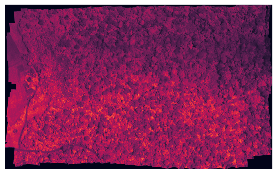

```python
show(ortho)
```

## Mapa de profundidade

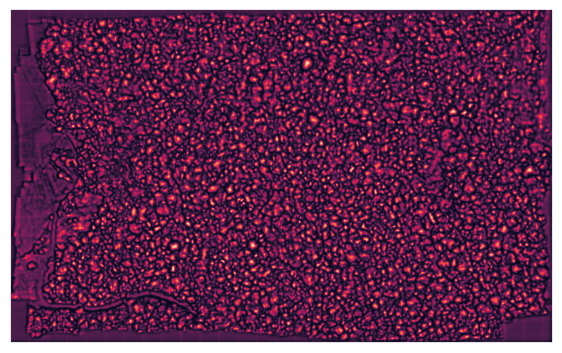

```
(4043, 6570)
```

```python
fig, ax = plt.subplots(figsize=(7,15))
ax.imshow(depth)
ax.set_xticks([])
ax.set_yticks([])
plt.show()
depth.shape
```

```python
depth.min(), depth.max()
```

```
(0.010177612, 0.98291016)
```

## Mapa de probabilidade

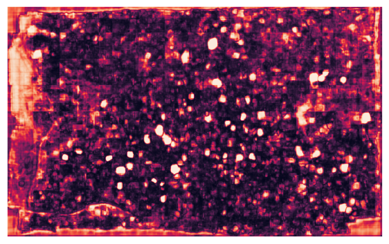

```
(4043, 6570)
```

```python
fig,ax = plt.subplots(figsize=(7,15))
ax.imshow(prob)
ax.set_xticks([])
ax.set_yticks([])
plt.show()
prob.shape
```

## Mapa de probabilidade com alta probabilidade de acerto

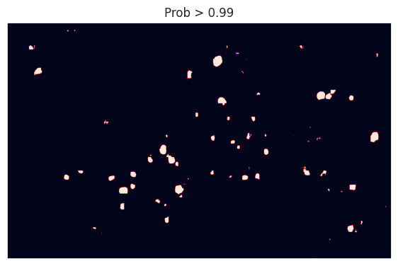

```python
fig, ax = show(np.where(prob > 0.99, prob, 0))
ax.set_title("Prob > 0.99")
plt.show()
```

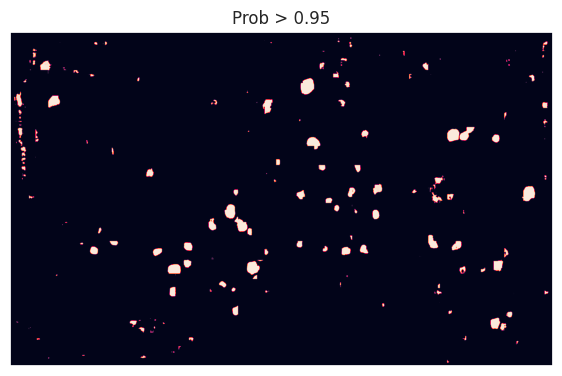

```python
fig, ax = show(np.where(prob > 0.95, prob, 0))
ax.set_title("Prob > 0.95")
plt.show()
```

## Visão das classes previstas

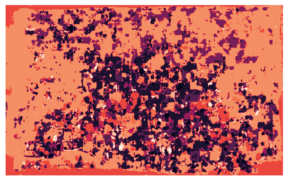

```python
fig, ax = show(pred)
# set legend for each label
labels = np.unique(pred)
plt.show()
```

```python
np.unique(pred)
```

```
array([ 0,  1,  2,  3,  4,  5,  6,  7,  8,  9, 10, 11, 12, 13],
      dtype=uint8)
```

# Labels Reais

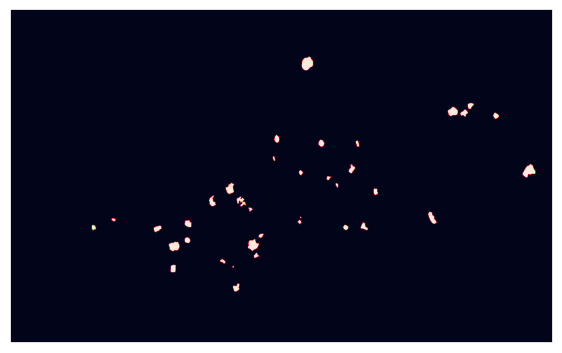

```python
ref = ground_truth_label.copy()

ref[ref>0] = 1

fig,ax = show(ref)
plt.show()
```

## Classes previstas com alta probabilidade de acerto

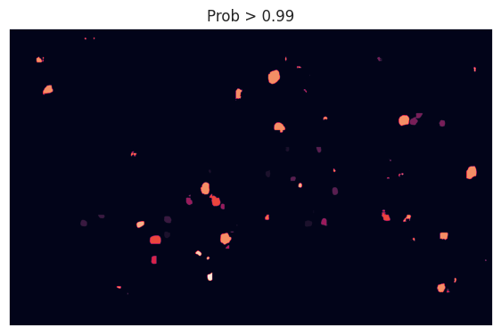

```python
fig,ax = show(np.where(prob < 0.99, 0, pred))
ax.set_title("Prob > 0.99")
plt.show()
```

# Comparação entre as Segmentações Reais e as geradas pelo modelo

## Comparação das labels geradas

```python
np.unique(pred)
```

```
array([ 0,  1,  2,  3,  4,  5,  6,  7,  8,  9, 10, 11, 12, 13],
      dtype=uint8)
```

```python
np.unique(ground_truth_label)
```

```
array([ 0,  1,  2,  3,  4,  5,  6,  7,  8,  9, 10, 11, 12, 13, 14],
      dtype=uint8)
```

Entranhamente, temos uma quantidade diferente de classes entre os valores preditos e os reais

```
(<Figure size 700x1500 with 1 Axes>, <Axes: >)
```

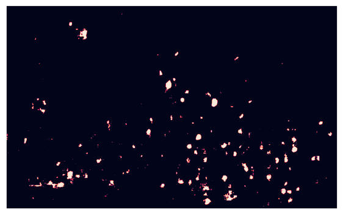

```python
show(pred==0)
```

Detectamos que esse suposto erro ocorre pois a classe 0 nas labels previsa pelo modelo, é uma classe de árvore.

Diante disso, faremos o tratamento para os dados de previsão estejam no mesmo formato dos dados reais

```python
pred+=1
```

```python
np.unique(pred)
```

```
array([ 1,  2,  3,  4,  5,  6,  7,  8,  9, 10, 11, 12, 13, 14],
      dtype=uint8)
```

```python
pred_map_99 = np.where(prob > 0.99, pred, 0)
```

Como sanity check, comparei a segmentação real com a segmentação gerada da classe 1

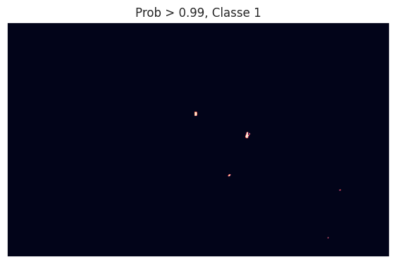

```python
ref = pred_map_99.copy()
ref[ref!=1] = 0
fig,ax=show(ref)
ax.set_title("Prob > 0.99, Classe 1")
plt.show()
```

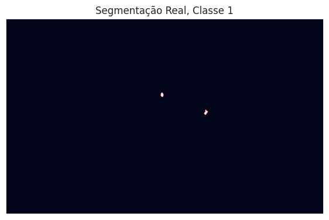

```python
ref = ground_truth_label.copy()
ref[ref!=1] = 0
fig,ax=show(ref)
ax.set_title("Segmentação Real, Classe 1")
plt.show()
```

## Obtendo estatísticas da segmentação

```python
properties = [
    "area",
    "convex_area",
    "bbox_area",
    "extent",
    "solidity",
    "eccentricity",
    "orientation",
    "centroid",
    "bbox",
    "label",
    "intensity_mean",
]
```

```python
components_gt_label = label(ground_truth_label)

stats_gt_data = pd.DataFrame(regionprops_table(components_gt_label, properties=properties, intensity_image=ground_truth_label))

stats_gt_data.rename(columns={"intensity_mean": "tree_type"}, inplace=True)
stats_gt_data["tree_type"] = stats_gt_data["tree_type"].astype(int)

stats_gt_data.set_index("label", inplace=True)
stats_gt_data.shape
```

```
(38, 14)
```

```python
components_pred_map = label(pred_map_99)

stats_pred_data = pd.DataFrame(regionprops_table(components_pred_map, properties=properties, intensity_image=pred_map_99))

stats_pred_data.rename(columns={"intensity_mean": "tree_type"}, inplace=True)
stats_pred_data["tree_type"] = stats_pred_data["tree_type"].astype(int)

stats_pred_data.set_index("label", inplace=True)
stats_pred_data.shape
```

```
(93, 14)
```

```python
print("Quantidade de árvores nas amostras originais:")
print(np.unique(components_gt_label).shape[0])

print("Quantidade de árvores nas amostras preditas:")
print(np.unique(components_pred_map).shape[0])
```

```
Quantidade de árvores nas amostras originais:
39
Quantidade de árvores nas amostras preditas:
94
```

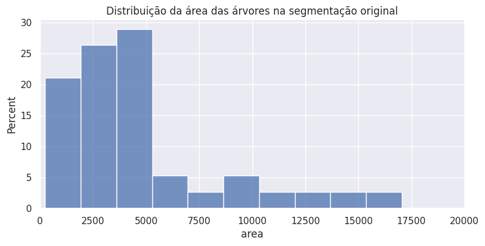

```
count       38.00
mean      4666.74
std       3919.89
min        236.00
25%       2140.50
50%       3765.00
75%       5134.25
max      17050.00
Name: area, dtype: float64
```

```python
sns.displot(stats_gt_data, x="area", kind="hist",height=4, aspect=2, bins=10, ax=ax, stat="percent")
plt.title("Distribuição da área das árvores na segmentação original")
# limit in x axis
plt.xlim(0, 20_000)
plt.show()
stats_gt_data["area"].describe().round(2)
```

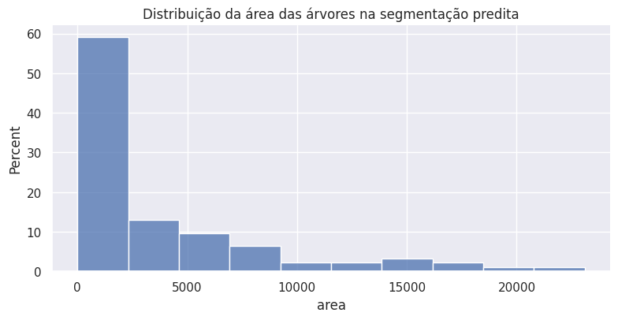

```
count       93.000000
mean      3629.741935
std       5097.683316
min          4.000000
25%        186.000000
50%       1103.000000
75%       5669.000000
max      23099.000000
Name: area, dtype: float64
```

```python
sns.displot(stats_pred_data, x="area", kind="hist",height=4, aspect=2, bins=10, ax=ax, stat="percent")
plt.title("Distribuição da área das árvores na segmentação predita")
plt.show()
stats_pred_data["area"].describe()
```

```python
print("Quantil 0.01 da segmentação original:")
stats_gt_data["area"].quantile(0.01)
```

```
Quantil 0.01 da segmentação original:
```

```
269.3
```

Como na segmentação original a menor área que obtemos é 236.

```python
print("Quantidade componentes com área menor que 236:")
(stats_pred_data["area"] < 250).sum()
```

```
Quantidade componentes com área menor que 236:
```

```
28
```

```python
filter = stats_pred_data["area"] < 200

components_to_remove = np.array(stats_pred_data[filter].index.astype(int))


for idx in components_to_remove:
    pred_map_99[components_pred_map == idx] = 0
    components_pred_map[components_pred_map == idx] = 0

# remove from dataframe
stats_pred_data = stats_pred_data[~filter]
```

Também temos árvores muito maiores que as que temos na base de segmentação

Veremos se faz sentido manter essa amostras muito maiores.

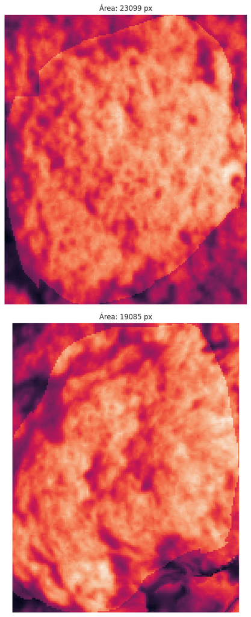

```python
filter = stats_pred_data["area"] > stats_gt_data["area"].max()

components_to_see = np.array(stats_pred_data[filter].index.astype(int))

mapa = np.zeros_like(components_pred_map)

shape_trees = components_pred_map.copy()

shape_trees[shape_trees>0] = 1

fig, ax = plt.subplots(figsize=(7,15), nrows=components_to_see.shape[0])

for num, idx in enumerate(components_to_see):


    bbox_0 = stats_pred_data.loc[idx, "bbox-0"]
    bbox_1 = stats_pred_data.loc[idx, "bbox-1"]
    bbox_2 = stats_pred_data.loc[idx, "bbox-2"]
    bbox_3 = stats_pred_data.loc[idx, "bbox-3"]

    pred_cut = shape_trees[bbox_0: bbox_2, bbox_1:bbox_3].copy()
    ortho_cut = ortho[bbox_0: bbox_2, bbox_1:bbox_3].copy()
    # pred_cut = shape_trees[components_pred_map == idx].copy()
    # ortho_cut = ortho[components_pred_map == idx].copy()

    ortho_cut+= pred_cut*255*(1/10)

    mapa[bbox_0: bbox_2, bbox_1:bbox_3] = pred_cut

    ax[num].imshow(ortho_cut)
    ax[num].set_xticks([])
    ax[num].set_yticks([])
    ax[num].set_title(f"Área: {stats_pred_data.loc[idx, 'area']:.0f} px")

plt.tight_layout()
plt.show()
```

Pelo que vemos, as áreas muito grandes estão fazendo a segmentação corretamente

## Comparação entre a razão entre áreas convexas e áreas dos componentes

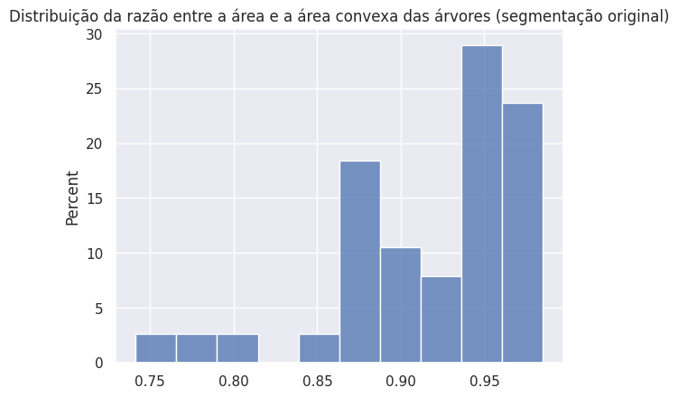

```
count    38.00
mean      0.92
std       0.06
min       0.74
25%       0.89
50%       0.94
75%       0.96
max       0.98
dtype: float64
```

```python
sns.histplot(stats_gt_data["area"]/stats_gt_data["convex_area"], bins=10, stat="percent")
plt.title("Distribuição da razão entre a área e a área convexa das árvores (segmentação original)")
plt.show()
(stats_gt_data["area"]/stats_gt_data["convex_area"]).describe().round(2)
```

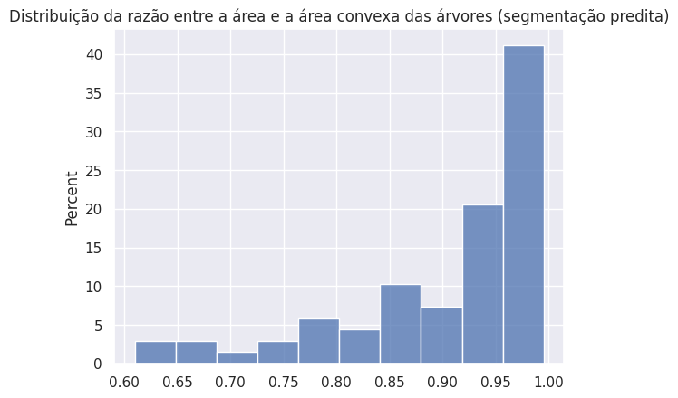

```
count    68.000000
mean      0.902399
std       0.097014
min       0.610083
25%       0.869120
50%       0.944683
75%       0.969772
max       0.995319
dtype: float64
```

```python
sns.histplot(stats_pred_data["area"]/stats_pred_data["convex_area"], bins=10, stat="percent")
plt.title("Distribuição da razão entre a área e a área convexa das árvores (segmentação predita)")
plt.show()
(stats_pred_data["area"]/stats_pred_data["convex_area"]).describe()
```

Percebemos que algumas labels geradas estão com a razão abaixo de 0.89 - o primeiro quartil da distribuição original.

Diante disso, veremos se esses casos estão fazendo a segmentação corretamente

```python
stats_pred_data["area_by_convex"] = stats_pred_data["area"]/stats_pred_data["convex_area"]
stats_pred_data.sort_values(by="area_by_convex", inplace=True)
```

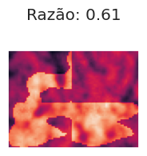

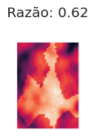

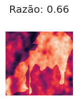

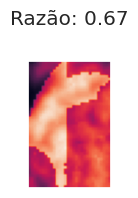

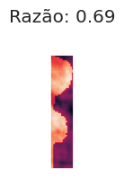

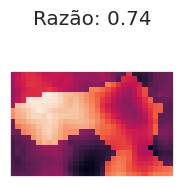

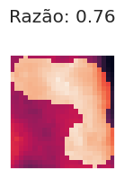

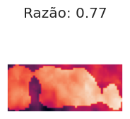

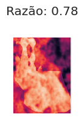

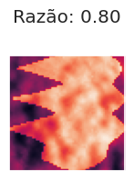

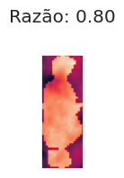

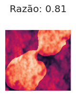

[12 more figures not shown]

```python
filter = (stats_pred_data["area"]/stats_pred_data["convex_area"]) < 0.9

components_to_see = np.array(stats_pred_data[filter].index.astype(int))

mapa = np.zeros_like(components_pred_map)

shape_trees = components_pred_map.copy()

shape_trees[shape_trees>0] = 1


for num, idx in enumerate(components_to_see):
    bbox_0 = stats_pred_data.loc[idx, "bbox-0"]
    bbox_1 = stats_pred_data.loc[idx, "bbox-1"]
    bbox_2 = stats_pred_data.loc[idx, "bbox-2"]
    bbox_3 = stats_pred_data.loc[idx, "bbox-3"]

    pred_cut = shape_trees[bbox_0: bbox_2, bbox_1:bbox_3].copy()
    ortho_cut = ortho[bbox_0: bbox_2, bbox_1:bbox_3].copy()
    ortho_cut+= pred_cut*255*(2/10)

    mapa[bbox_0: bbox_2, bbox_1:bbox_3] = pred_cut

    fig, ax = show(ortho_cut)
    fig.suptitle(f"Razão: {stats_pred_data.loc[idx, 'area']/stats_pred_data.loc[idx,'convex_area']:.2f}")
    fig.set_size_inches(2,2)
    plt.tight_layout()
    plt.show()
```

Como podemos ver, a partir de 0.85 a segmentação começa a ser feita de forma correta

Então, cortaremos qualquer label com $\frac{\text{area}}{\text{área convexa}} \leq 0.85$

```python
filter = (stats_pred_data["area"]/stats_pred_data["convex_area"]) < 0.85

components_to_remove = np.array(stats_pred_data[filter].index.astype(int))

for idx in components_to_remove:

    # remove from imagem
    pred_map_99[components_pred_map == idx] = 0
    # remove from components
    components_pred_map[components_pred_map==idx] = 0

# remove from dataframe
stats_pred_data = stats_pred_data.drop(components_to_remove)
```

# Comparação das distribuição de espécies

Identificando a espécie de cada árvore

```python
components_to_iter = stats_pred_data.index.astype(int)

for idx in components_to_iter:

    count_tree_types =  np.unique(pred_map_99[components_pred_map == idx], return_counts=True)

    count_tree_types = pd.Series(count_tree_types[1], index=count_tree_types[0])
    # drop index with 0
    count_tree_types = count_tree_types[count_tree_types.index != 0]
    count_tree_types.sort_values(ascending=False, inplace=True)
    # obtem o index que mais aparece
    stats_pred_data.loc[idx, "tree_type"] = count_tree_types.index[0].astype(int)






components_to_iter = stats_gt_data.index.astype(int)

for idx in components_to_iter:

    count_tree_types =  np.unique(ground_truth_label[components_gt_label==idx], return_counts=True)
    count_tree_types = pd.Series(count_tree_types[1], index=count_tree_types[0])
    # drop index with 0
    count_tree_types = count_tree_types[count_tree_types.index != 0]
    count_tree_types.sort_values(ascending=False, inplace=True)
    # obtem o index com mais counts
    stats_gt_data.loc[idx, "tree_type"] = count_tree_types.index[0].astype(int)
```

```python
count_tree = pd.concat(
    [
        stats_pred_data["tree_type"].value_counts().astype("Int64"),
        stats_gt_data["tree_type"].value_counts().astype("Int64"),
    ],
    axis=1,
)

count_tree.columns = ["count_predito", "count_real"]
count_tree.sort_index(inplace=True)
count_tree["diferença"] = count_tree["count_predito"] - count_tree["count_real"]
count_tree
```

| tree_type | count_predito | count_real | diferença |
| --- | --- | --- | --- |
| 1 | 5 | 2 | 3 |
| 2 | 6 | 4 | 2 |
| 3 | 3 | 3 | 0 |
| 4 | 3 | 3 | 0 |
| 5 | 1 | 3 | -2 |
| 6 | 4 | 3 | 1 |
| 7 | 1 | 1 | 0 |
| 8 | 1 | 1 | 0 |
| 9 | 1 | 4 | -3 |
| 10 | 1 | 4 | -3 |
| 11 | 21 | 5 | 16 |
| 12 | 3 | 3 | 0 |
| 13 | 1 | 1 | 0 |
| 14 | 1 | 1 | 0 |

Quantidade de árvores após o filtro

```python
print("Quantidade de árvores nas amostras originais:")
print(np.unique(components_gt_label).shape[0])

print("Quantidade de árvores nas amostras preditas:")
print(np.unique(components_pred_map).shape[0])
```

```
Quantidade de árvores nas amostras originais:
39
Quantidade de árvores nas amostras preditas:
53
```

# Construção do banco de labels

Adicionaremos ao conjunto as labels com alta confiança com base em nossas premissas.

Na construção do conjunto serão mantidas as árvore do conjunto de treino original

```python
all_label_set = ground_truth_label.copy()

label_delta = np.zeros_like(all_label_set)

components_to_iter = stats_pred_data.index.astype(int)

for idx in components_to_iter:
    # se mais de 90% do componente é vazio será adicionado a nova amostra predita
    if np.mean(components_gt_label[components_pred_map==idx] == 0) > 0.9:
        class_count = np.unique(pred_map_99[components_pred_map==idx], return_counts=True)

        class_count = pd.Series(class_count[1], index=class_count[0]).sort_values(ascending=False)
        class_common = class_count.index[0]
        # print(class_common)
        all_label_set[components_pred_map==idx] = class_common
        label_delta[components_pred_map==idx] = class_common
```

## Contagem da quantidade de árvores a mais

```python
# Seleção de components para melhorar
components_label_delta = label(label_delta)
stats_label_delta = pd.DataFrame(regionprops_table(components_label_delta, properties=properties, intensity_image=pred_map_99))
stats_label_delta.rename(columns={"intensity_mean": "tree_type"}, inplace=True)

print("Quantidade de árvores adicionadas na amostra:")
stats_label_delta.shape[0]
```

```
Quantidade de árvores adicionadas na amostra:
```

```
22
```

# Seleção das labels para manter balanceamento

```python
def undersample(data, column_category):
    X = data.drop(column_category, axis=1).copy()
    y = data[column_category].copy()
    # define undersample strategy
    undersample_selector = RandomUnderSampler(sampling_strategy='majority', random_state=42)
    # fit and apply the transform
    X, y = undersample_selector.fit_resample(X, data[column_category])

    # summarize class distribution
    # columns_namem = X.columns.tolist()+[column_category]
    return pd.concat([X, y], axis=1)
```

```python
stats_und_label_delta = undersample(stats_label_delta, "tree_type")

stats_und_label_delta = stats_und_label_delta.astype({"tree_type": "int64"})

stats_und_label_delta.set_index("label", inplace=True)
```

## Adição das novas labels com as classes balanceadas

```python
label_for_next_iter = ground_truth_label.copy()

for idx in stats_und_label_delta.index.astype(int):
    label_for_next_iter[components_label_delta==idx] = stats_und_label_delta.loc[idx, "tree_type"]

    if np.mean(components_gt_label[components_label_delta==idx] == 0) > 0.9:
        class_count = np.unique(pred_map_99[components_label_delta==idx], return_counts=True)
        class_count = pd.Series(class_count[1], index=class_count[0]).sort_values(ascending=False)

        label_for_next_iter[components_label_delta==idx] = class_count.index[0]

    # show(label_next_iter)
```

```
(<Figure size 700x1500 with 1 Axes>, <Axes: >)
```

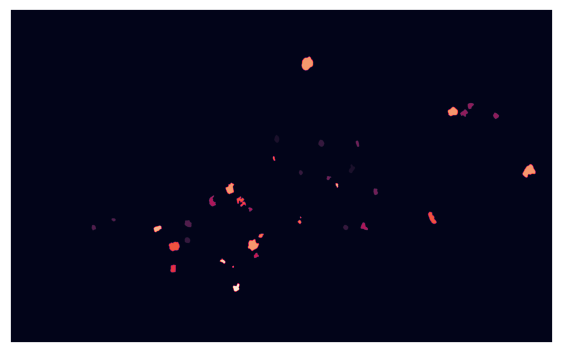

```python
show(ground_truth_label)
```

```
(<Figure size 700x1500 with 1 Axes>, <Axes: >)
```

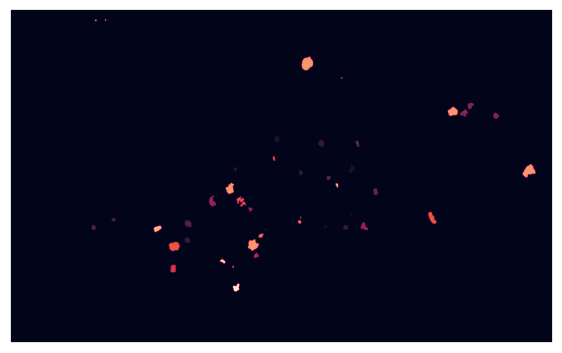

```python
show(label_for_next_iter)
```

## Aplicando mapa de distâncias

```python
from scipy.ndimage import distance_transform_edt
from scipy.ndimage import gaussian_filter
```

```python
ref = label_for_next_iter.copy()

ref[ref>0] = 1
# generate the distance map
label_ref = label(ref)
new_lab = label_ref.copy()
# Aplica mapa de distância
new_lab = distance_transform_edt(new_lab)
# Aplica filtro gaussiano
new_lab = gaussian_filter(new_lab, sigma=5)

# substitui os valores de label_ref pelos valores de new_lab
save_lab = np.zeros(label_ref.shape)
for obj in np.unique(label_ref)[1:]:
    save_lab[label_ref==obj] = new_lab[label_ref==obj]/np.max(new_lab[label_ref==obj])
```

Versão final para próxima iteração

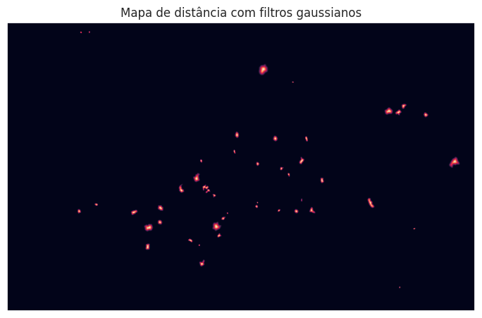

```python
fig, ax = show(save_lab)
ax.set_title("Mapa de distância com filtros gaussianos")

plt.tight_layout()
plt.show()
```

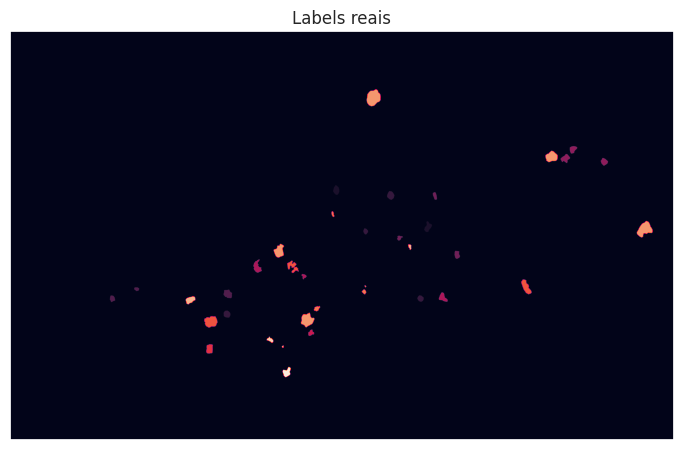

```python
fig,ax = show(ground_truth_label)
ax.set_title("Label real")
plt.title("Labels reais")
plt.tight_layout()
plt.show()
```

# Compile html

```python
!jupyter nbconvert --to html "data_process_between_iter.ipynb" --output-dir "../reports/"
```